# Fordgobike-Tripdata Explaination

# Productivity of ages and types of them.

## the main key insight is which age or ages more productive?

## which age or ages more frequent?

when we count ages we find that age 31 is the most frequent with 10236 user,  
and then 26 years old with 9325 user and then 30 with 8972 , 29 with 8658  
31, 26, 30 is more frequent than others

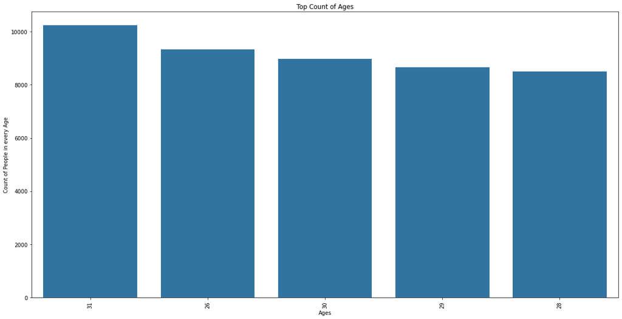

# which age or ages we need to care about in frequent or which less frequent?

alot of ages we need to care about if it more productive than others in another side.

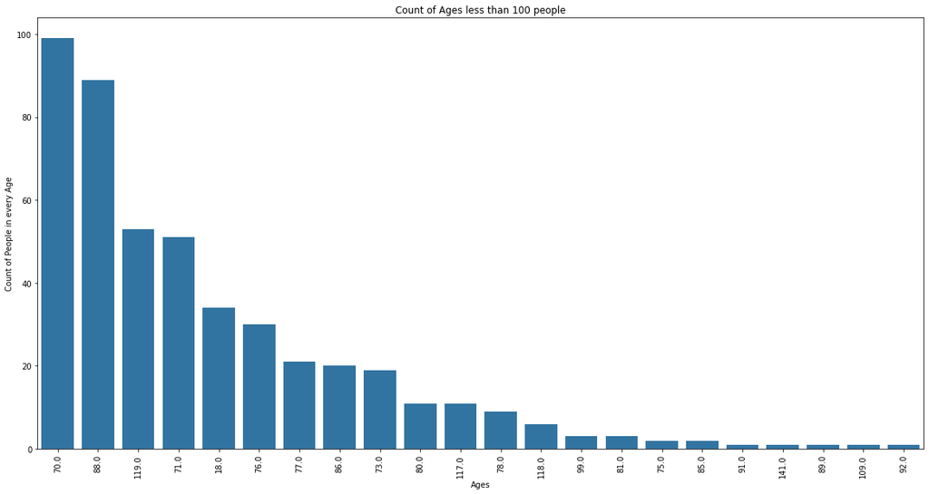

the figure above is for ages with count less than 100 people.  
alot of ages we need to care about if it more productive than others in another side.  
ages counts less than 100 people 18 years old which is more productive in another side ,and  
76, 77, 86, 73, 117, 80, 78, 118, 81, 99, 85, 75, 91, 109, 89, 92, 141, 70, 88, 119, 71 years old

# which ages counts of it between mean and median ?

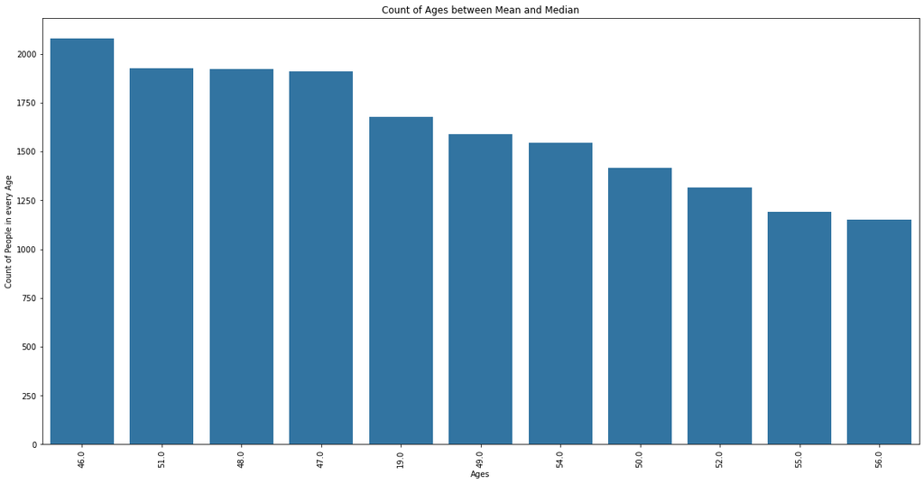

counts between mean and median in this ages 19 , range ages 46:52 and range ages 54:56

# is ages between mean and median far away from the top heighst ages?

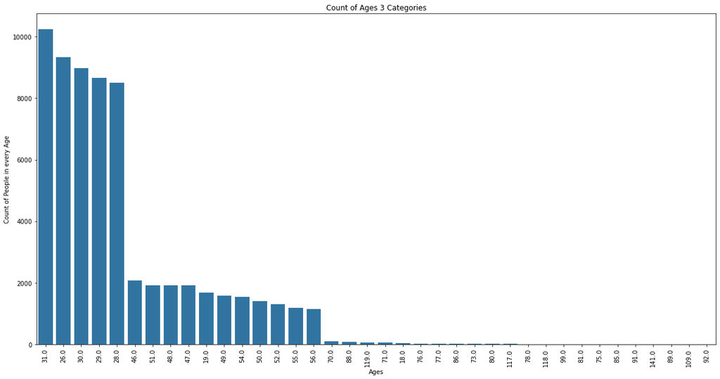

the figure above determine that the top heighst counts more than 3 times  
the counts between mean and median  
that explain that we focus only in range ages 26 to 31 years old  
but we dont care about alot of data we need to care about

# the big picture

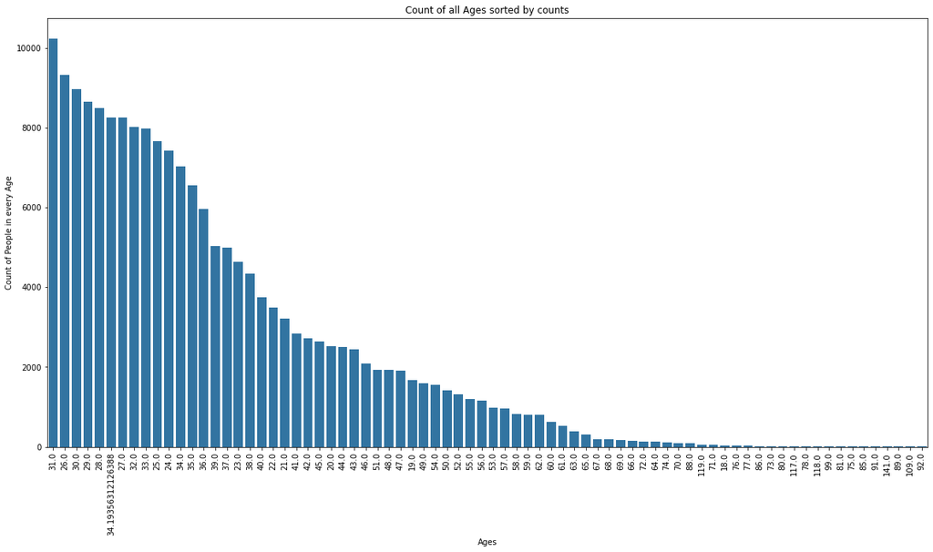

the figure above determine all counts to ages in all data.

# what is the shape of count of ages in all data sorted by ages?

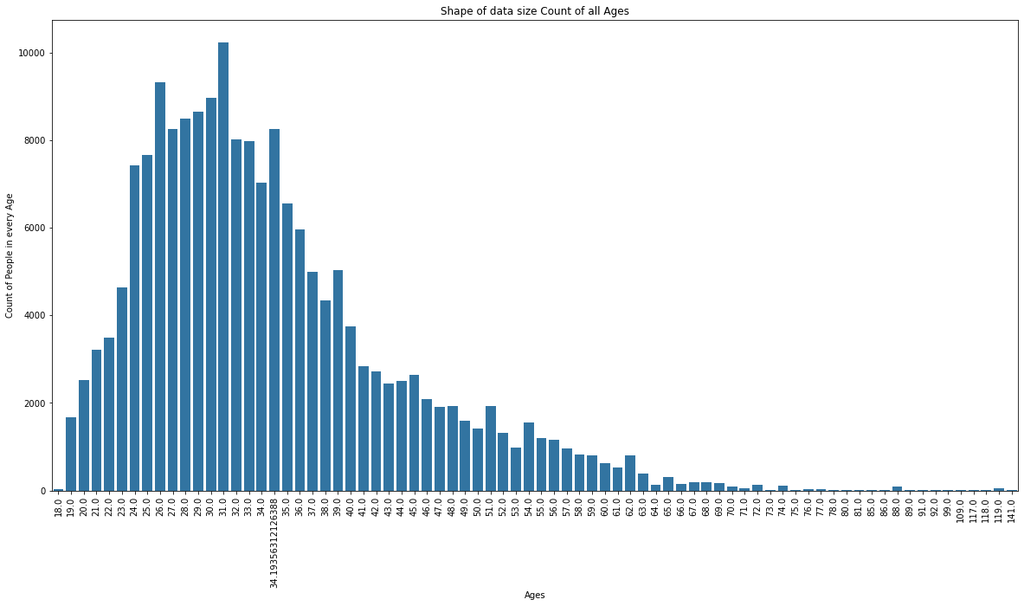

the shape of data is right skewd from age 18 to 141 the average of ages is 34 years old. count of age increase from 18 to 31 and then decrease.

# what ages counts of it above mean ?

# and what ages counts of it above median?

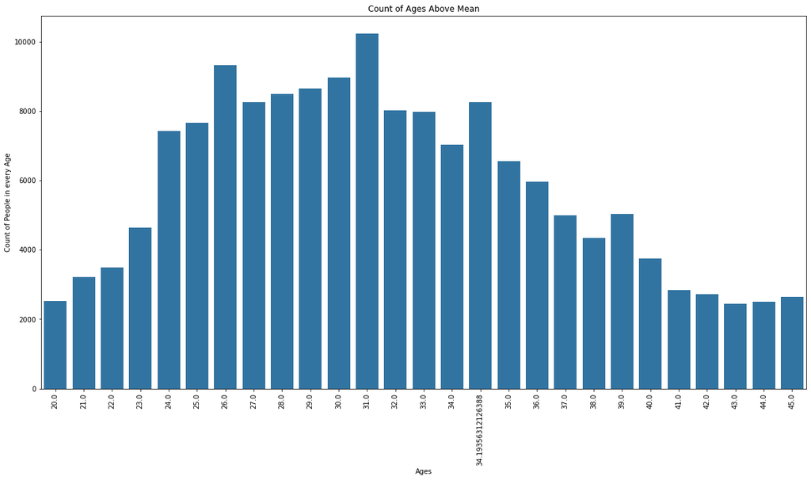

range ages above mean from 20 to 45 years old.

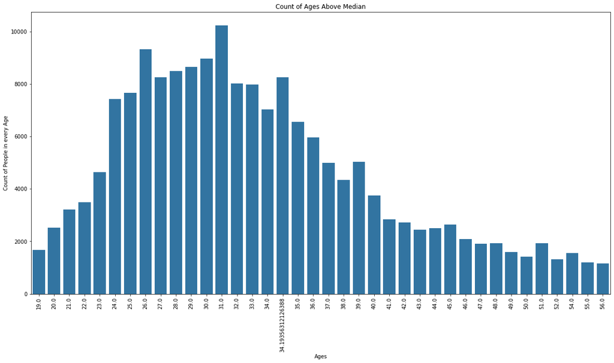

range ages above median from 19 to 56 where the destribution is right skewd more than mean.

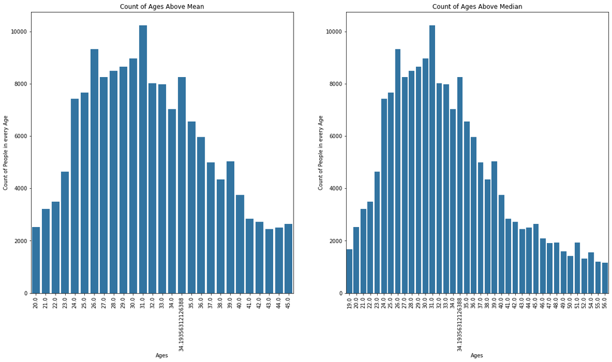

# which range of ages is compine most the data ?

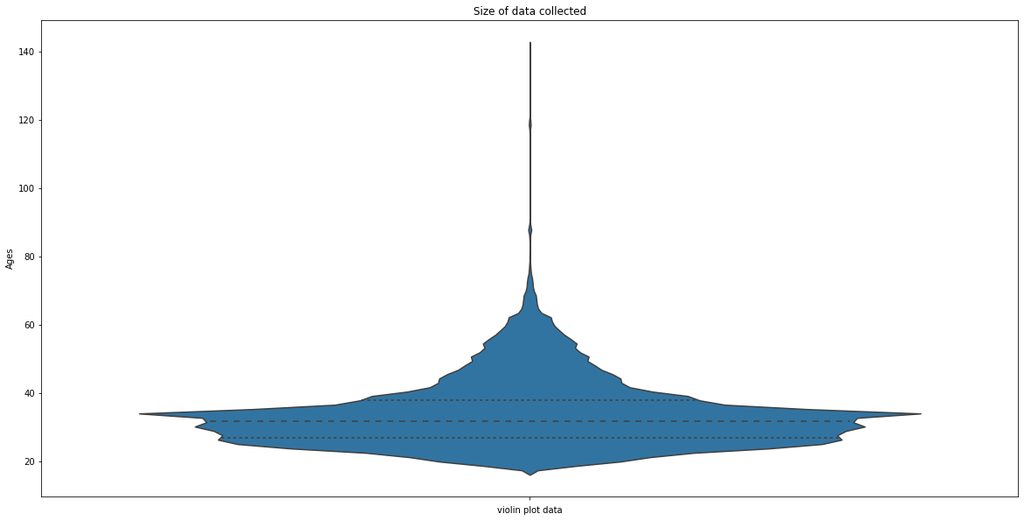

# if there any groups of ages seems to be like each other?

### count counts if any count frequent as group of something every time

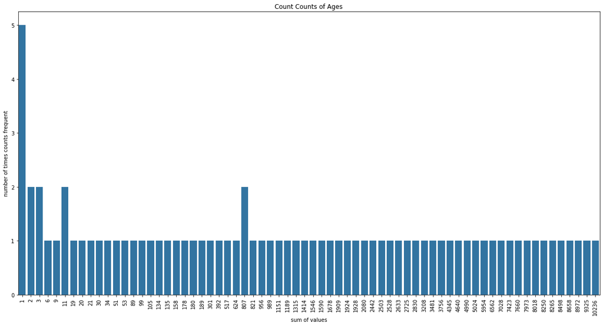

count 11 people for ages 117, 80 and count 807 people for ages 59, 62 years old.

# counts people whats the shape of it when we talk about range ages in this data?

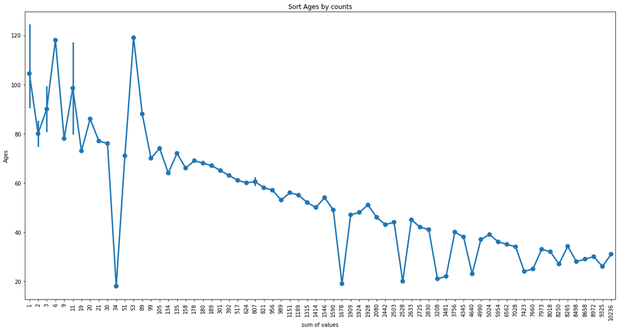

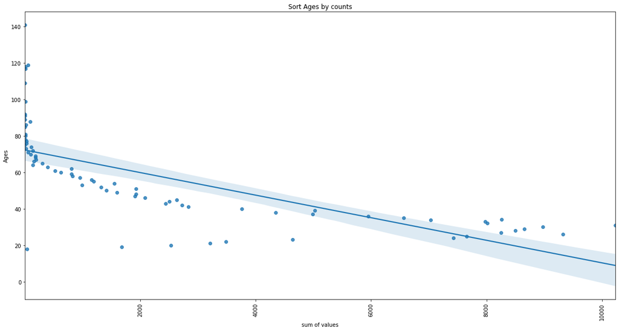

the shape above explain when the age increase the count of people in this age decrease.

# what range of ages in this data when we talk about counts?

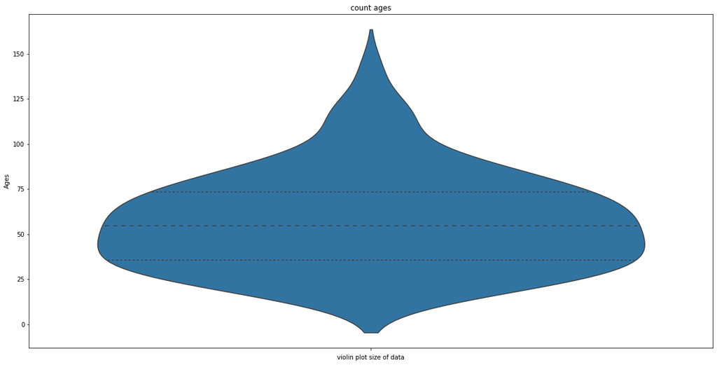

approxemately range of counts people between 20 and 80 years old.

# which ages more productive in duration seconds?

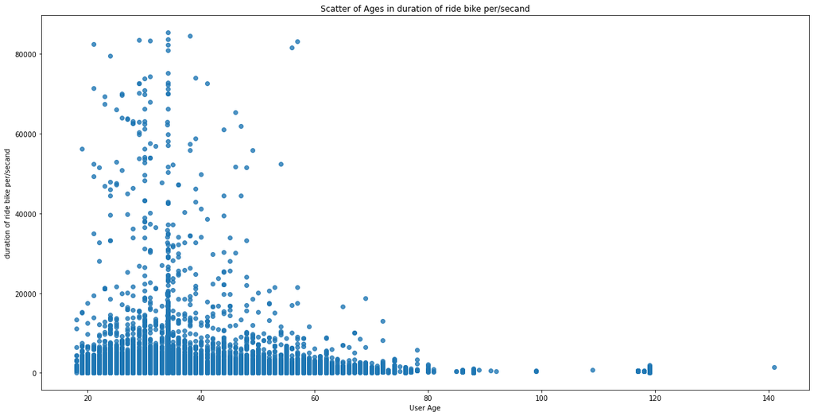

when we talk about duration second in this data approxemately more people between 18 and 65 years old.

# what is the mean of duration second of every age?

# and why age 18 is more productive less count ?

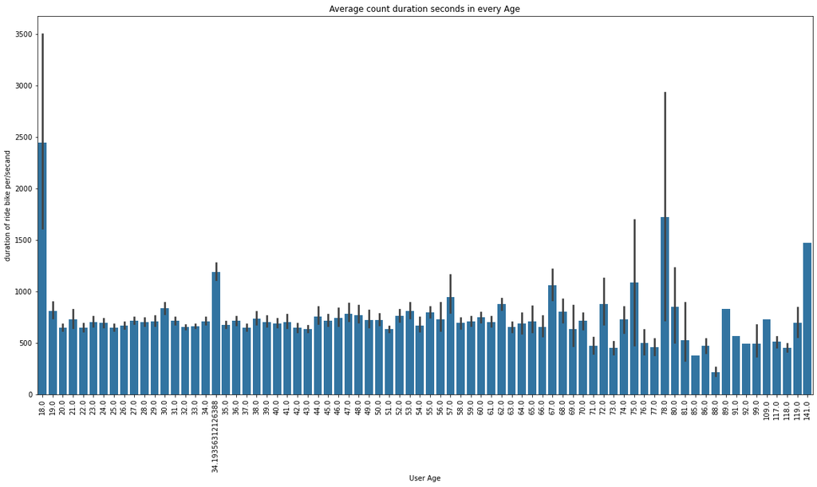

average of age 18 years old is greater than others when we talk about duration sec.

when we want more duration second its important to focus on age 18 years old in our marketing. because of average more productive in duration of second and now there only 34 person in this data.

# what count of duration second of every age? and what is the shape of it?

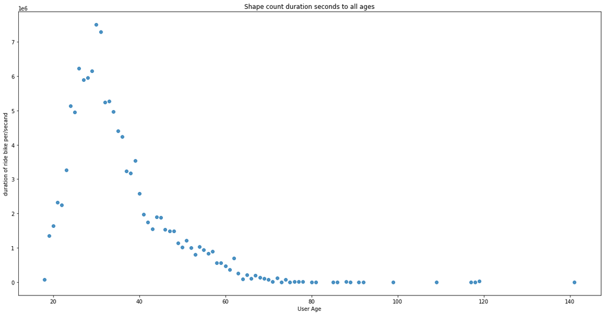

the shape determine the counts of duration second of every age the shape is right skewd from fewest range ages to largest.

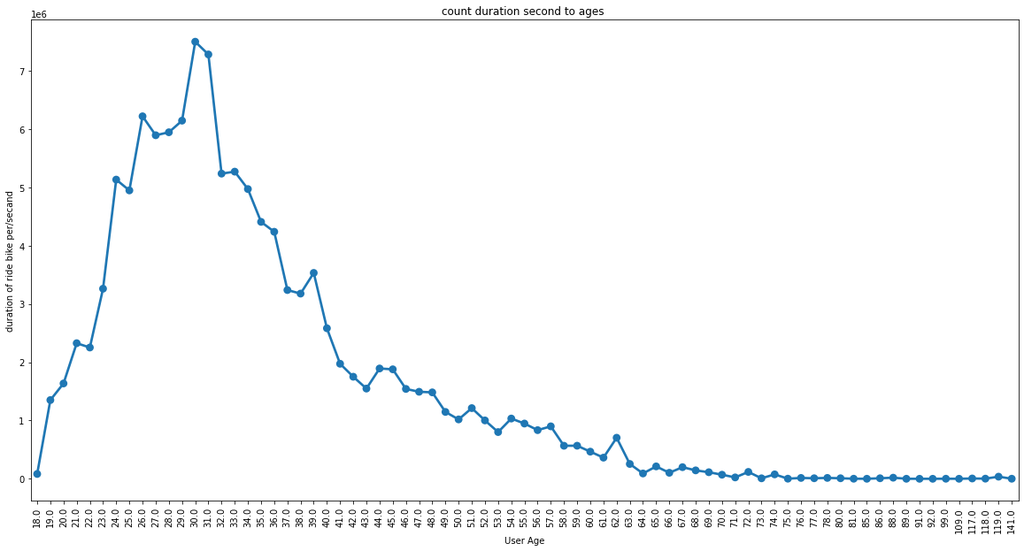

count duration second is more between 19 and 48 years old from 48 to 63 years old decrease and then be few above 63 years old.

# what is porportion of top count duration for ages ?

# and what count duration more productive?

sum of duration better in this range of ages 26:31 years old which its porporthion of count duration_sec is 31.6% .

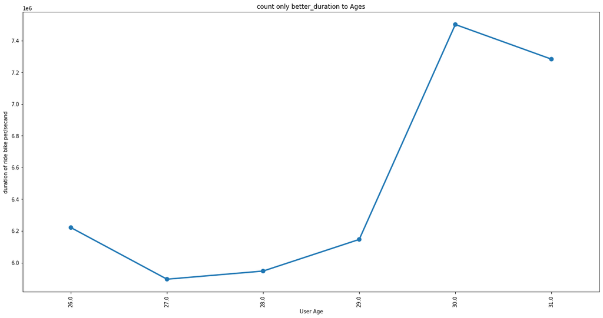

30 and 31 ages is more productive when we talk to duration second; but it is not surprise because approxemately this 2 ages come to ride more than others especialy 31 years old with 10236 person.

# what range of ages counts duration second is above or equal mean?

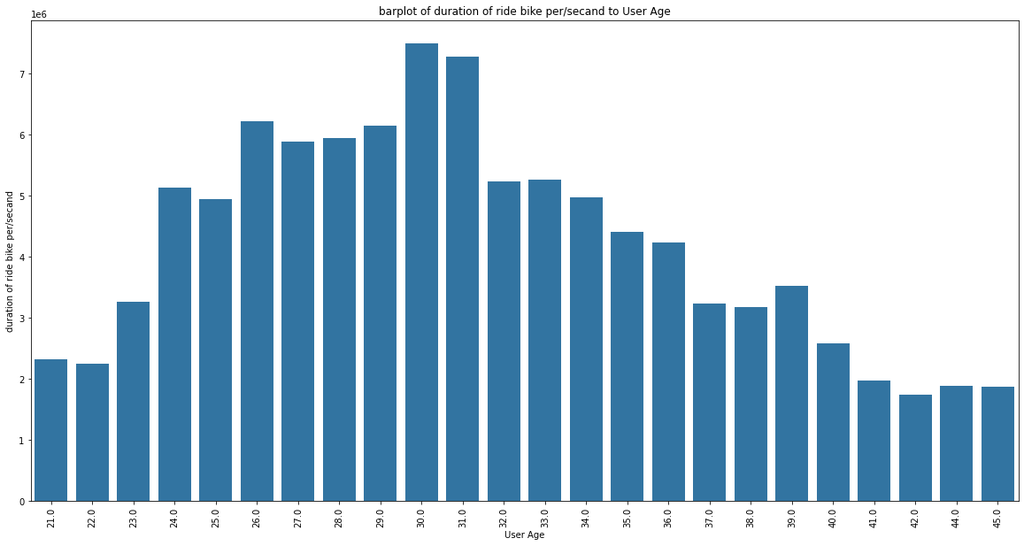

from 21 to 45 years old greater than or equal to the mean of duration second.

# what size of half data as type customers ?

# and what size of half data as type supscribers when we talk about ages?

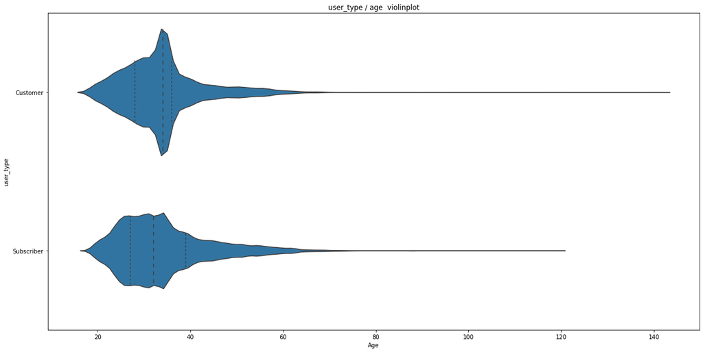

aproxemetly all of data combined between 20 and 40 years old  
half of customers between 28 and 36 years old  
half of subscribers between 27 and 39 years old

# what type is more productive?

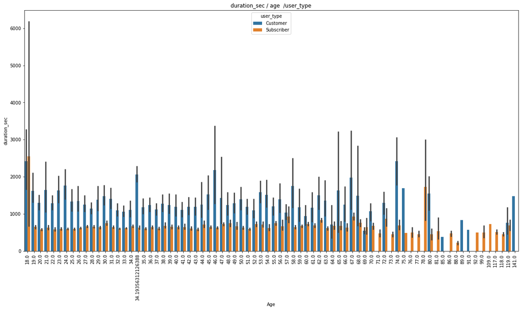

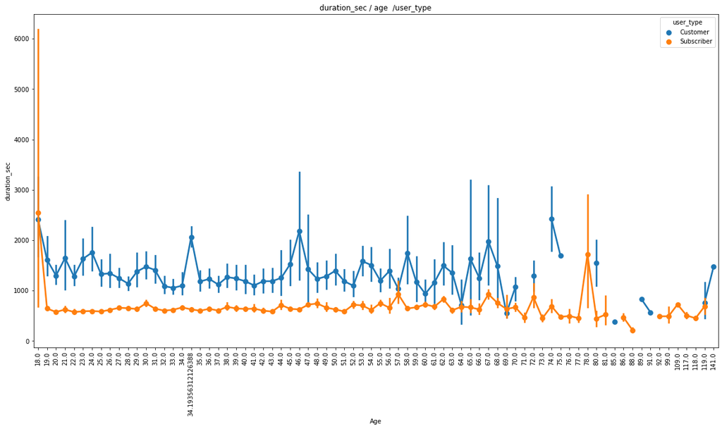

we see now that customers are more productivity when we talk about duration second than subscribers.